# StatData1: forelæsning d. 7/9-2022

Anders Tolver

# Lineær regression

Vi benytter datasættet `cats` fra R pakken MASS

```r
library(MASS)
data(cats)
```

Data vedrører 144 katte. Der er tre variable datasættet

- Køn: `Sex`
- Kropsvægt i kg: `Bwt`
- Vægt af hjerte i gram `Hwt`

```r
head(cats, n = 3) # udskriver de først tre datalinjer
```

```
##   Sex Bwt Hwt
## 1   F   2 7.0
## 2   F   2 7.4
## 3   F   2 9.5
```

Vi forestiller os, at kropsvægten `Bwt` kan være nyttig, hvis man ønsker at forudsige værdien af hjertevægten `Hwt`.

Regressionsanalyse handler netop om, at beskrive sammenhængen mellem to kvantitative variable med henblik på at forklare responsen (her: `Hwt`) ud fra en forklarende variabel (her: `Bwt`).

**Linear regression** giver mening, hvis sammenhængen mellem respons og forklarende variabel er tilnærmelsesvis lineær. Vi starter med at plotte data (scatterplot!) for at vurdere om sammenhængen er lineær …

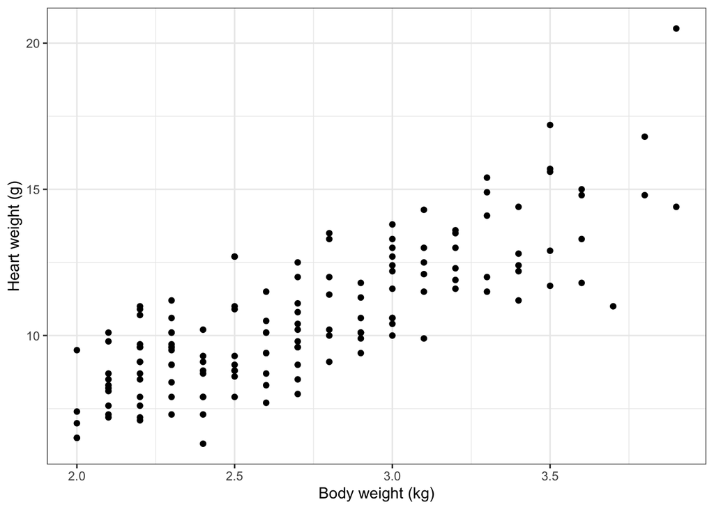

```r
library(ggplot2)
ggplot(data = cats) + geom_point(aes(x = Bwt, y = Hwt)) + theme_bw() + labs(x = "Body weight (kg)", y = "Heart weight (g)")
```

Datapunkterne ligger (naturligvis) ikke fuldstændigt på en ret linje, men det virker ikke urimeligt at benytte lineær regression.

## Fit af regressionslinje

Vi ønsker at bestemme en ligning af formen

y = a * x + b

som bedst muligt kan forudsige y (=hjertevægt), hvis man kender x (=kropsvægt).

For at bestemme regressionslinjen, så skal vi *estimere* (dvs. beregne) værdien af *parametrene* a og b ud fra datapunkterne. Hertil benyttes `lm()` funktionen, der benyttes sig af *mindste-kvadraters-metode*

```r
linreg <- lm(Hwt ~ Bwt, data = cats) ### estimer regressionslinje
linreg ### udskriv resultat
```

```
##
## Call:
## lm(formula = Hwt ~ Bwt, data = cats)
##
## Coefficients:
## (Intercept)          Bwt
##     -0.3567       4.0341
```

Heraf aflæses

- Estimatet for linjens skæring `(Intercept)`: -0.3566624
- Estimatet for linjens hældning `Bwt`: 4.0340627

**Fortolkning af regressionslinje:** For to (grupper af) katte med en forskel på 1 kg i kropsvægt, så vil vi alt andet lige gætte på, at at kattene som vejer mest også har en forøget hjertevægt på 4.0341 g i gennemsnit.

## Indtegn fittet regressionslinje på scatterplot

Med standardgrafik kan man tegne et scatterplot, men regresssionslinje indtegnet på følgende måde

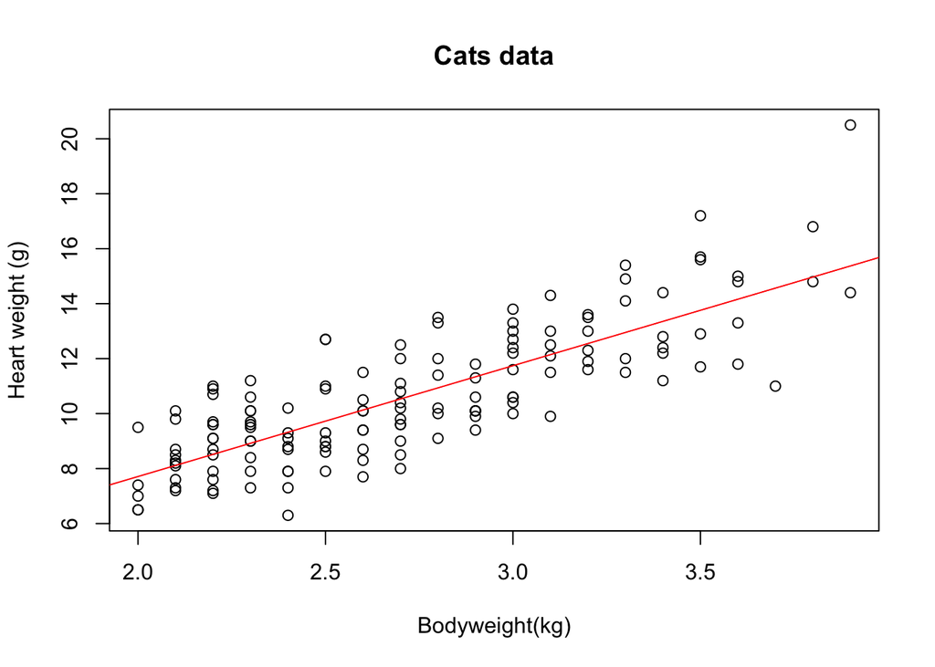

```r
plot(cats$Bwt, cats$Hwt, xlab = "Bodyweight(kg)", ylab = "Heart weight (g)", main = "Cats data")
abline(-0.3567, 4.0341, col = "red")
```

```r
plot(cats$Bwt, cats$Hwt, xlab = "Bodyweight(kg)", ylab = "Heart weight (g)", main = "Cats data")
abline(linreg, col = "red")
```

# Korrelationer

Hvis man måler to kvantitative variable (x og y), så kan man være interesseret i at beskrive sammenhængen mellem de to. Lineær regression forudsætter, at man enten ønsker at forklare y ud fra x eller x ud fra y, men i mange situationer er variablene x og y ligeværdige.

Korrelationskoefficienten forsøger at måle graden af (den lineære) sammenhæng mellem x og y, uden at vi tager stilling til om y eller x skal være responsvariablen.

I praksis undersøger man med korrelationskoefficienten om observationer med en særlig stor værdi af x (dvs. over populationsgennemsnittet) også typisk har en særlig stor værdi af y (dvs. over populationsgenemsnittet). Den præcise formel for korrelationskoefficienten er særlig god til at fange en sammenhæng mellem x og y, hvis scatterplottet for (x,y) tyder på en lineær sammenhæng mellem variablene.

Om brug af korrelationskoefficienten bemærkes

- at den primært bør bruges, hvis scatterplottet for (x,y) antyder en lineær sammenhæng
- at den altid ligger mellem -1 og 1
- at den er 0, hvis der ikke er nogen (lineær) information om y i x eller omvendt
- at den er +1 (eller -1), hvis punkterne ligger perfekt på en linje med positiv (eller negativ) hældning

Vi har ovenfor set, at der ser ud til at være en lineær sammenhæng mellem kropsvægt (`Bwt`) og hjertevægt (`Hwt`).

Korrelationskoefficienten beregnes

```r
cor(cats$Bwt, cats$Hwt) ### korrelationskoefficient
```

```
## [1] 0.8041274
```

Korrelationskoefficienten antyder en positiv sammenhæng mellem kropsvægt og hjertevægt: høj kropsvægt og høj hjertevægt har en tendens til at optræde sammen!

# Ensidet variansanalyse

Hvis man har målt værdien af en kvantitativ kontinuert variabel og målingerne er inddelt i grupper på baggrund af en kategorisk variable, så vil man ofte være interesseret i, at sammenligne grupperne. Mere præcist: er værdien af den kontinuerte (respons-)variabel ens i de forskellige grupper?

Datasættet `antibio` beskrevet på dagens forelæsningsslides (7/9-2022) indeholder målinger af mængden af organisk materiale (`org`) i gødning fra 36 kvier, som er inddelt i seks grupper (`type`). Grupperne angiver hvilken type antibiotikum, som har været tilsat til kviernes foder. Gruppen `type = Control` angiver, at der ikke har været tilsat antibiotikum til foderet.

Et udpluk at data ses her

```r
library(isdals)
data(antibio)
head(antibio, n=7)
```

```
##       type  org
## 1 Ivermect 3.03
## 2 Ivermect 2.81
## 3 Ivermect 3.06
## 4 Ivermect 3.11
## 5 Ivermect 2.94
## 6 Ivermect 3.06
## 7  Alfacyp 3.00
```

Vi ønsker at forklare variationen i mængden af organisk stof ud fra en ene forklarende (kategoriske) variable `type`. Ensidet variansanalyse er en metode, der er velegnet til denne problemstilling.

## Boxplot

Start altid med at visualisere data, så man kan se

- variationen inden for grupperne
- variationen mellem grupperne

Et boxplot fokuserer på at vise variationen vha. fraktilerne i fordelingen …

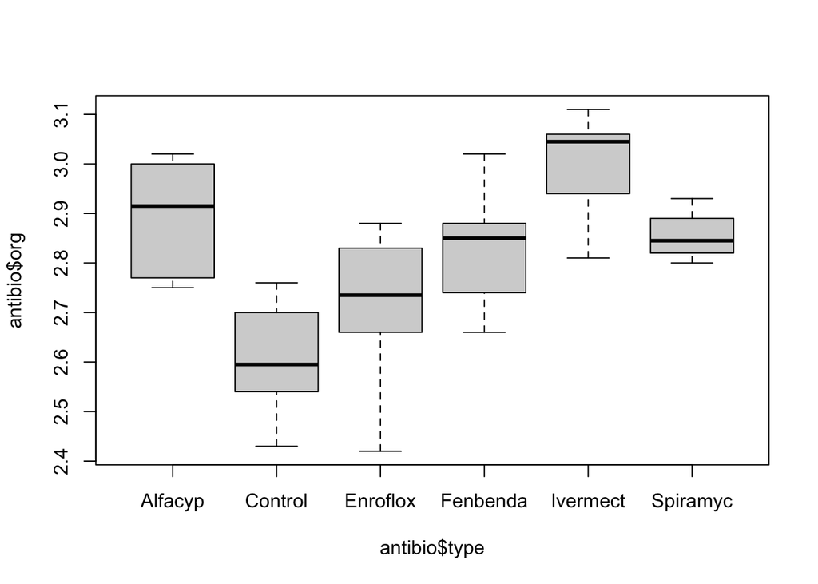

```r
boxplot(antibio$org ~ antibio$type)
```

Der er noget forskel på median-værdierne af `org` for gødning fra de forskellige `typer`. Udfordringen ligger dog i, at der også er en del variation inden for hver fodergruppe (`type`).

Senere på kurset taler vi om objektive metoder til at udtale sig om, hvorvidt der er væsentlig forskel på grupperne, når det kommer til indholdet af organisk materiale.

## Ensidet ANOVA (udregning af gruppegennesnit)

En ensidet variansanalyse (ANOVA) fokuserer på sammenligning af gruppegennemsnit. Funktionen `lm()` kan benyttes til at udregne gruppegennemsnit som følger …

```r
### fit af ensidet ANOVA, gruppegennemsnit
lm(org ~ type - 1, data = antibio)
```

```
##
## Call:
## lm(formula = org ~ type - 1, data = antibio)
##
## Coefficients:
##  typeAlfacyp   typeControl  typeEnroflox  typeFenbenda  typeIvermect
##        2.895         2.603         2.710         2.833         3.002
## typeSpiramyc
##        2.855
```

## Udregning af stikprøvestørrelse opdelt på gruppe

I forbindelse med ensidet variansanalyse (ANOVA) og i mange andre situationer kan det være nyttigg at kunne foretage beregninger af middelværdi, median osv. for en kontinuert variabel for hver gruppe, når man inddeler efter en kategorisk variabel.

R pakken `tidyverse` indeholder en mængde R funktioner, som er nyttige til at arbejde effektivt med data.

Her vises, hvordan man på baggrund af datasættet `antibio` kan udregne diverse summariske mål (stikprøvestørrelser) for responsvariablen `org` opdelt på fodergruppen (`type`). Sammenlign med middelværdierne, som blev udregnet med `lm()` funktionen ovenfor.

```r
library(tidyverse) ### indlæs "tidyverse" R pakken (skal installeres først!)
antibio <- as_tibble(antibio)
summarize(group_by(antibio, type), mean_org = mean(org), sd_org = sd(org), median_org = median(org))
```

```
## # A tibble: 6 × 4
##   type     mean_org sd_org median_org
##   <fct>       <dbl>  <dbl>      <dbl>
## 1 Alfacyp      2.90 0.117        2.92
## 2 Control      2.60 0.119        2.60
## 3 Enroflox     2.71 0.162        2.74
## 4 Fenbenda     2.83 0.124        2.85
## 5 Ivermect     3.00 0.109        3.04
## 6 Spiramyc     2.86 0.0545       2.84
```

Forklaring til R koden ovenfor (linje-for-linje)

- indlæs `tidyverse` R pakken
- lav `antibio` om til et objekt af type `tibble` (dette er nødvendigt for at man kan arbejde med funktionerne i R pakken `tidyverse`)
- udregn diverse summariske størrelser på datasættet `antibio`
  - hvor udregningerne fortages for hver `type`
  - `mean_org`: er middelværdien af `org`
  - `sd_org`: er spredningen af `org`
  - `median_org`: er medianværdien af `org`